# Descriptive Statistics

## Measures of Central Tendency, Variability, and Standard Scores

Understanding the central tendency and variability of data is crucial in descriptive statistics. These measures give us insights into the general pattern of the data, its central position, and its spread. Additionally, standard scores allow us to understand how individual data points relate to the distribution. Here’s a breakdown of how to calculate these statistics and their importance.

### Calculating Mean, Median, and Mode

The mean, median, and mode are measures of central tendency that describe the center of a data set.

- **Mean** is the average value and is affected by outliers.
- **Median** is the middle value in a data set when ordered from the smallest to the largest and is less affected by outliers.
- **Mode** is the most frequently occurring value in a data set and can be used for both numerical and categorical data.

**Example in R:**

```r
# Sample data
data <- c(2, 3, 3, 5, 7, 10, 11)

# Calculating mean
mean_value <- mean(data)
print(paste("Mean:", mean_value))
```

```
## [1] "Mean: 5.85714285714286"
```

```r
# Calculating median
median_value <- median(data)
print(paste("Median:", median_value))
```

```
## [1] "Median: 5"
```

```r
# Calculating mode
get_mode <- function(x) {
  uniqx <- unique(x)
  uniqx[which.max(tabulate(match(x, uniqx)))]
}
mode_value <- get_mode(data)
print(paste("Mode:", mode_value))
```

```
## [1] "Mode: 3"
```

### Variance, Standard Deviation, and Range

These are measures of variability that indicate the spread of data points.

- **Variance** measures the average squared deviation of each number from the mean. It gives a sense of how data is spread out.
- **Standard Deviation** is the square root of variance and provides a metric that is in the same units as the data.
- **Range** is the difference between the maximum and minimum values in the dataset.

**Example in R:**

```r
# Calculating variance
variance_value <- var(data)
print(paste("Variance:", variance_value))
```

```
## [1] "Variance: 12.8095238095238"
```

```r
# Calculating standard deviation
sd_value <- sd(data)
print(paste("Standard Deviation:", sd_value))
```

```
## [1] "Standard Deviation: 3.57903950935496"
```

```r
# Calculating range
range_value <- max(data) - min(data)
print(paste("Range:", range_value))
```

```
## [1] "Range: 9"
```

### Normalization and Standardization of Scores

Normalization and standardization are techniques to adjust the scale of data, which is crucial for many statistical techniques and data visualization.

- **Normalization** typically refers to the process of scaling data to have a minimum of 0 and a maximum of 1.
- **Standardization** (Z-score normalization) involves rescaling data to have a mean of 0 and a standard deviation of 1.

**Example in R:**

```r
# Normalization
normalize <- function(x) {
  (x - min(x)) / (max(x) - min(x))
}
normalized_data <- normalize(data)
print("Normalized Data:")
```

```
## [1] "Normalized Data:"
```

```r
print(normalized_data)
```

```
## [1] 0.0000000 0.1111111 0.1111111 0.3333333 0.5555556 0.8888889 1.0000000
```

```r
# Standardization
standardize <- function(x) {
  (x - mean(x)) / sd(x)
}
standardized_data <- standardize(data)
print("Standardized Data:")
```

```
## [1] "Standardized Data:"
```

```r
print(standardized_data)
```

```
## [1] -1.0777033 -0.7982988 -0.7982988 -0.2394896  0.3193195  1.1575332  1.4369378
```

### Graphical Representations

Visual tools like histograms and box plots are invaluable for understanding data distributions.

**Histogram Example:**

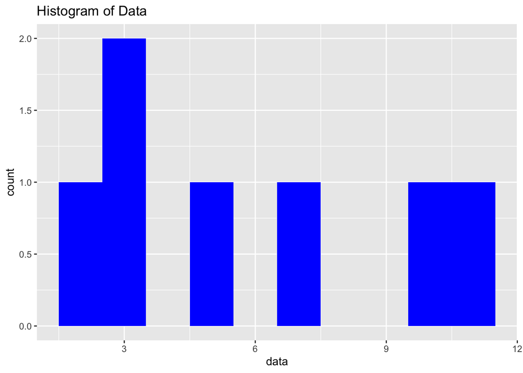

```r
library(ggplot2)
ggplot(data.frame(data), aes(x=data)) +
  geom_histogram(binwidth = 1, fill="blue") +
  ggtitle("Histogram of Data")
```

**Box Plot Example:**

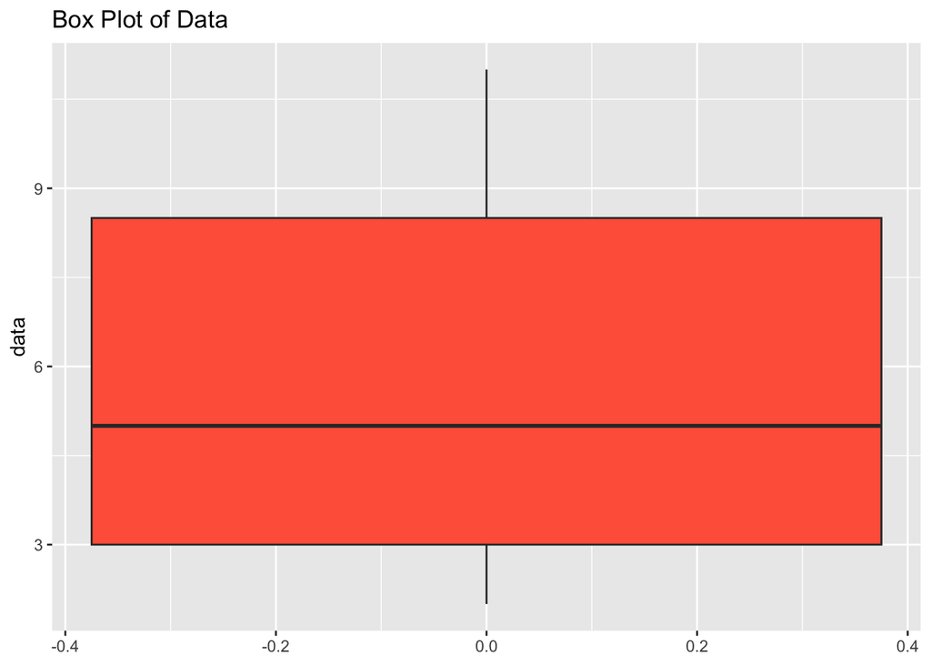

```r
ggplot(data.frame(data), aes(y=data)) +
  geom_boxplot(fill="tomato") +
  ggtitle("Box Plot of Data")
```

### Real-World Applications

In business, statistics guide decision-making processes; in science, they validate research findings.

# More on Visualizing Distributions and Relationships

Enhancing data visualization skills is crucial for analyzing and interpreting complex datasets. This section covers advanced visualization techniques like box plots, violin plots, density plots, scatter plots, correlograms, and introduces multidimensional scaling (MDS) and principal component analysis (PCA).

## Box Plots, Violin Plots, and Density Plots

These plots are essential for visualizing the distribution of data and identifying outliers.

### Box Plots

Box plots provide a graphical representation of the central tendency and variability of data, highlighting medians and quartiles.

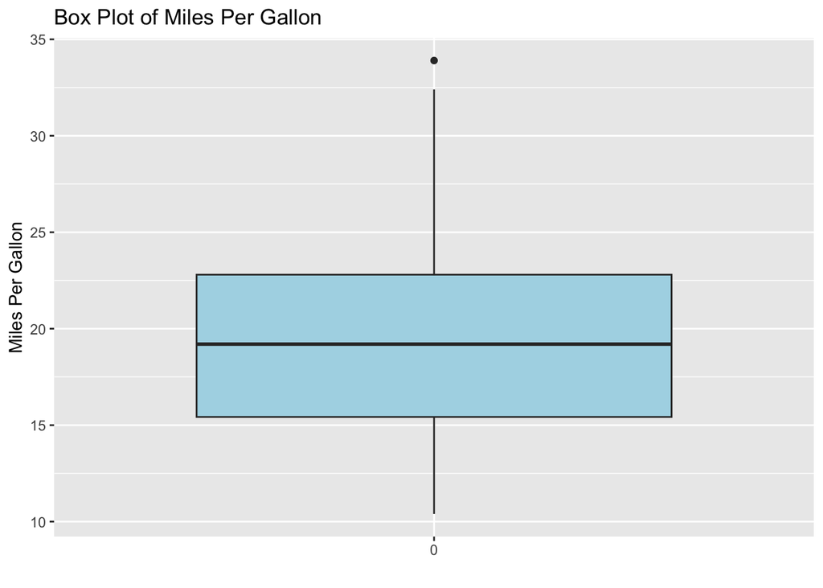

```r
library(ggplot2)

# Example of a Box Plot
data <- mtcars$mpg
ggplot(mtcars, aes(x = factor(0), y = data)) +
  geom_boxplot(fill = "lightblue") +
  labs(title = "Box Plot of Miles Per Gallon", x = "", y = "Miles Per Gallon")
```

### Violin Plots

Violin plots combine box plots and density plots, providing a deeper understanding of the density distribution.

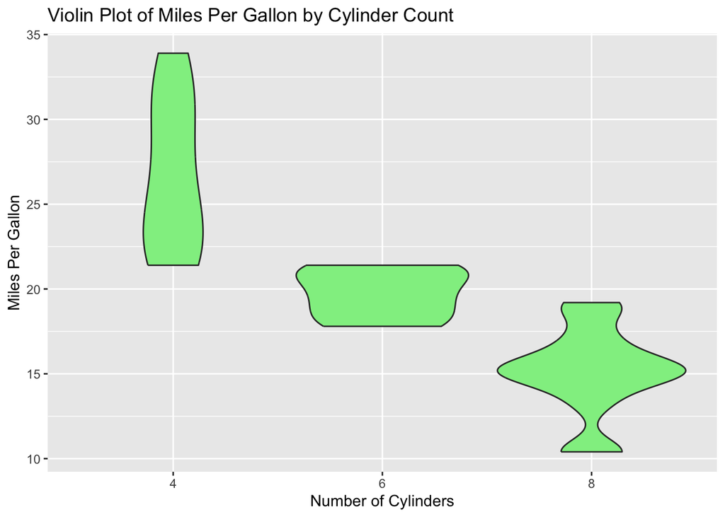

```r
# Example of a Violin Plot
ggplot(mtcars, aes(x = factor(cyl), y = mpg)) +
  geom_violin(fill = "lightgreen") +
  labs(title = "Violin Plot of Miles Per Gallon by Cylinder Count", x = "Number of Cylinders", y = "Miles Per Gallon")
```

### Density Plots

Density plots are smoothed, continuous versions of histograms that estimate the probability density function of a variable.

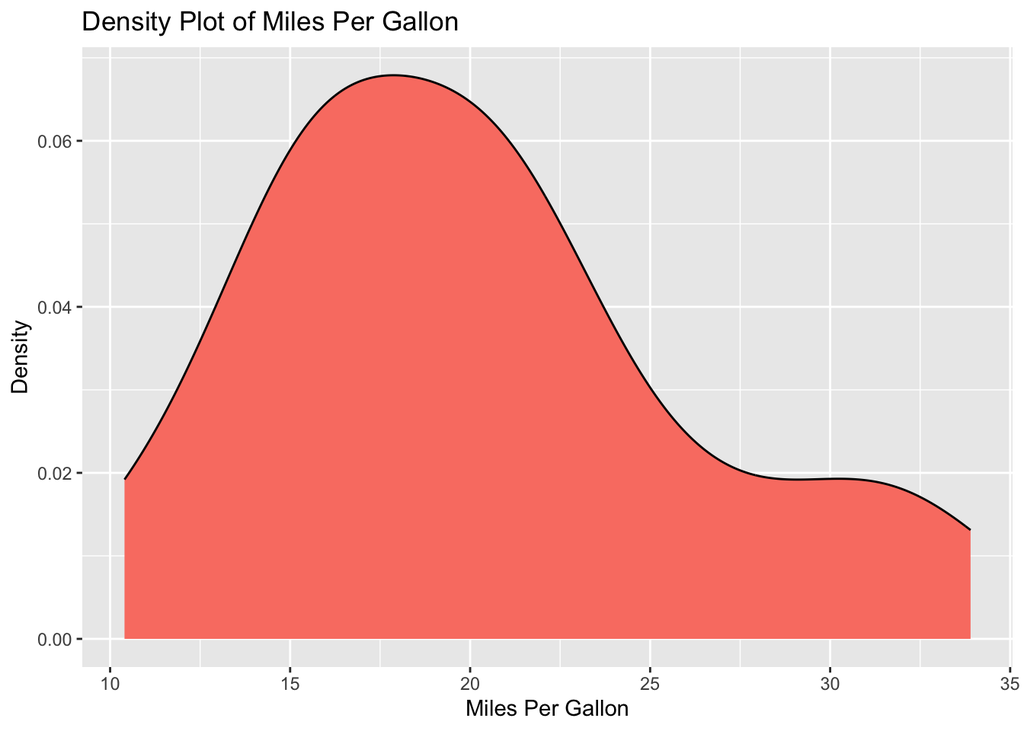

```r
# Example of a Density Plot
ggplot(mtcars, aes(x = mpg)) +
  geom_density(fill = "salmon") +
  labs(title = "Density Plot of Miles Per Gallon", x = "Miles Per Gallon", y = "Density")
```

## Pairwise Relationships with Scatter Plots and Correlograms

Understanding the relationships between multiple variables is crucial for many analytical tasks.

### Scatter Plots

Scatter plots allow for the visualization of relationships between two numeric variables.

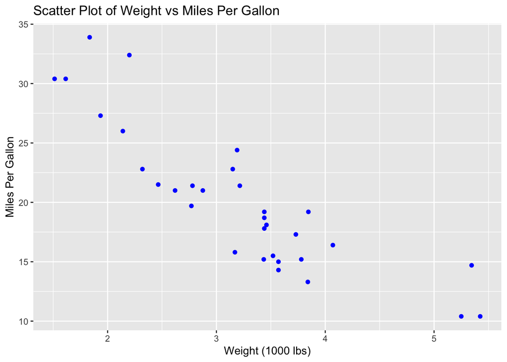

```r
# Example of a Scatter Plot
ggplot(mtcars, aes(x = wt, y = mpg)) +
  geom_point(color = "blue") +
  labs(title = "Scatter Plot of Weight vs Miles Per Gallon", x = "Weight (1000 lbs)", y = "Miles Per Gallon")
```

### Correlograms

Correlograms show the correlation coefficients between pairs of variables across an entire dataset, useful for feature selection.

```r
# Correlogram with the PerformanceAnalytics package
library(PerformanceAnalytics)
```

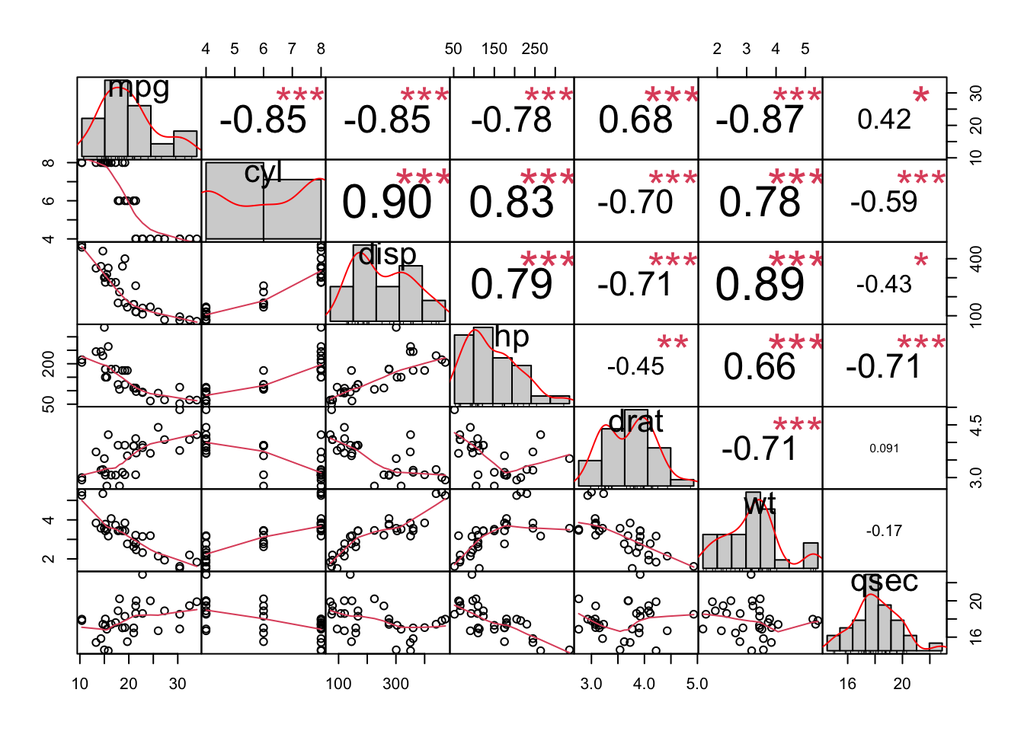

```r
chart.Correlation(mtcars[,1:7], histogram = TRUE, pch = 19)
```

## Introduction to Multidimensional Scaling and PCA

These techniques are used for dimensionality reduction, allowing for the visualization of complex, high-dimensional data in a lower-dimensional space.

### Multidimensional Scaling (MDS)

MDS projects high-dimensional data into a lower-dimensional space while preserving the distances among data points.

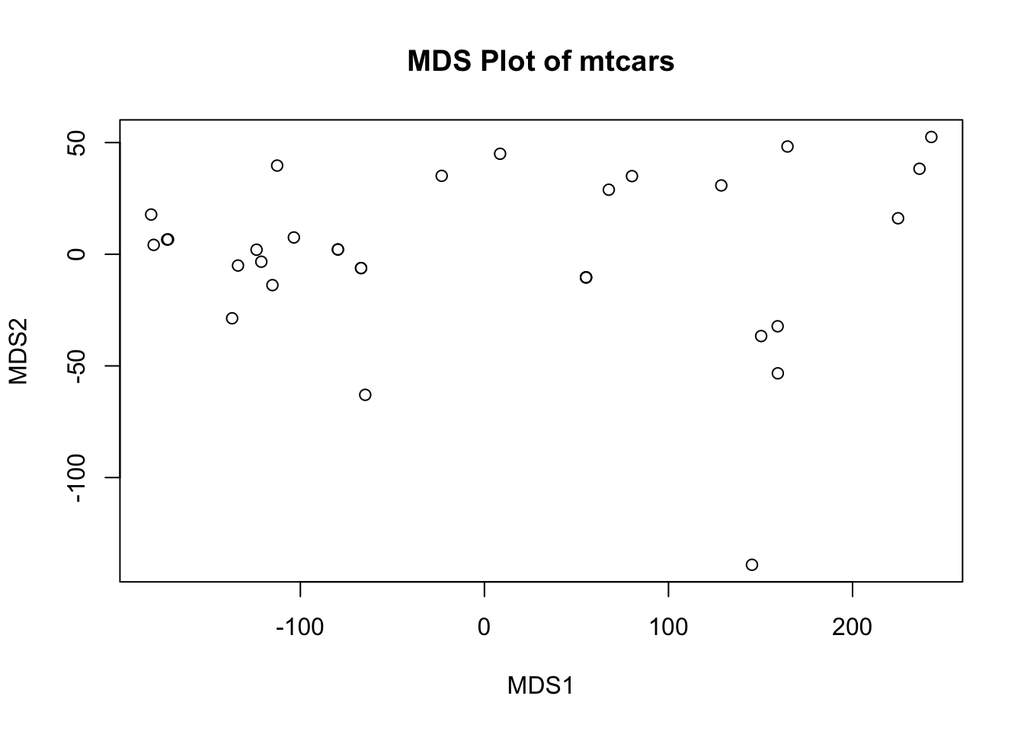

```r
# Example of MDS
distances <- dist(mtcars)  # Calculate Euclidean distances
mds_model <- cmdscale(distances)  # Classical MDS
plot(mds_model[,1], mds_model[,2], xlab = "MDS1", ylab = "MDS2", main = "MDS Plot of mtcars")
```

### Principal Component Analysis (PCA)

PCA reduces dimensionality by transforming variables into a new set of variables (principal components), which are linear combinations of the original variables.

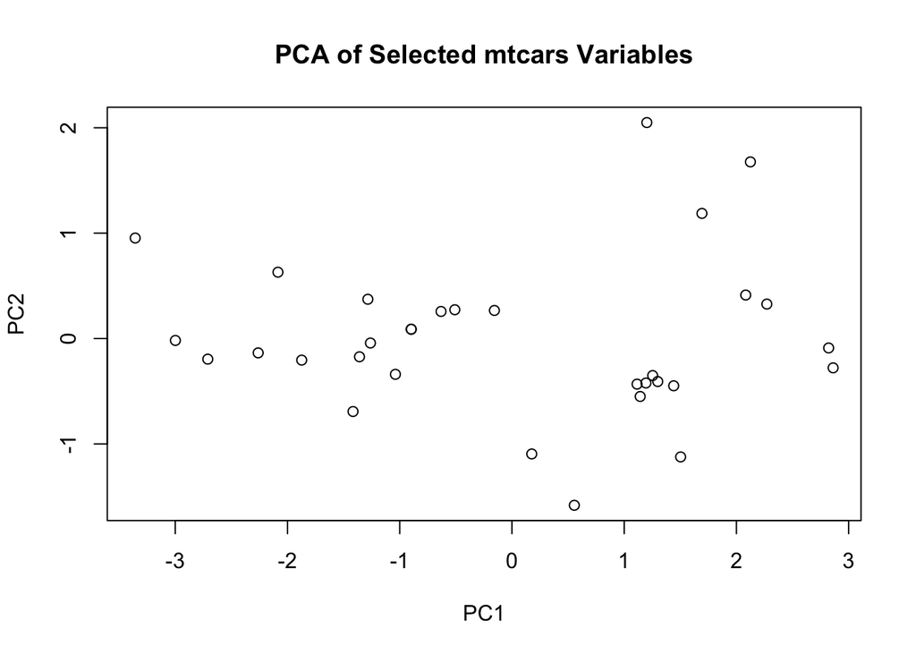

```r
# Example of PCA
pca_result <- prcomp(mtcars[, c("mpg", "disp", "hp", "drat")], scale. = TRUE)
plot(pca_result$x[,1:2], xlab = "PC1", ylab = "PC2", main = "PCA of Selected mtcars Variables")
```

## Visualizing Distributions and Relationships with the Iris Dataset

**Example: Apply Visualization Techniques** Given the `iris` dataset, create box plots for each species’ petal length, a correlogram for the dataset, and perform PCA to visualize the first two principal components.

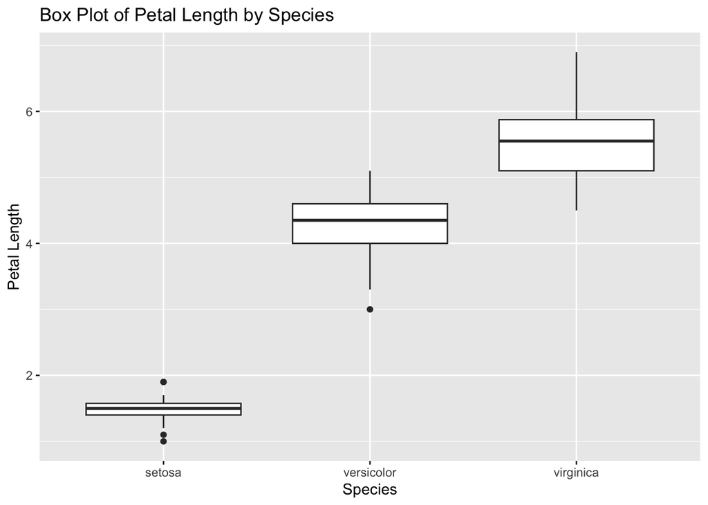

```r
# Load data
data(iris)

# Box plots for each species' petal length
ggplot(iris, aes(x = Species, y = Petal.Length)) +
  geom_boxplot() +
  labs(title = "Box Plot of Petal Length by Species", x = "Species", y = "Petal Length")
```

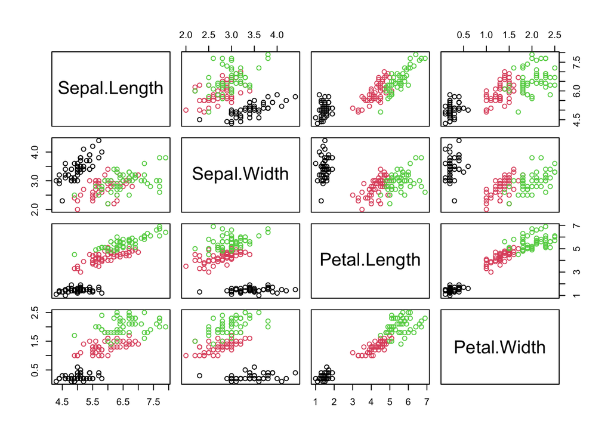

```r
# Correlogram for iris dataset
pairs(~Sepal.Length + Sepal.Width + Petal.Length + Petal.Width, data = iris, col = iris$Species)
```

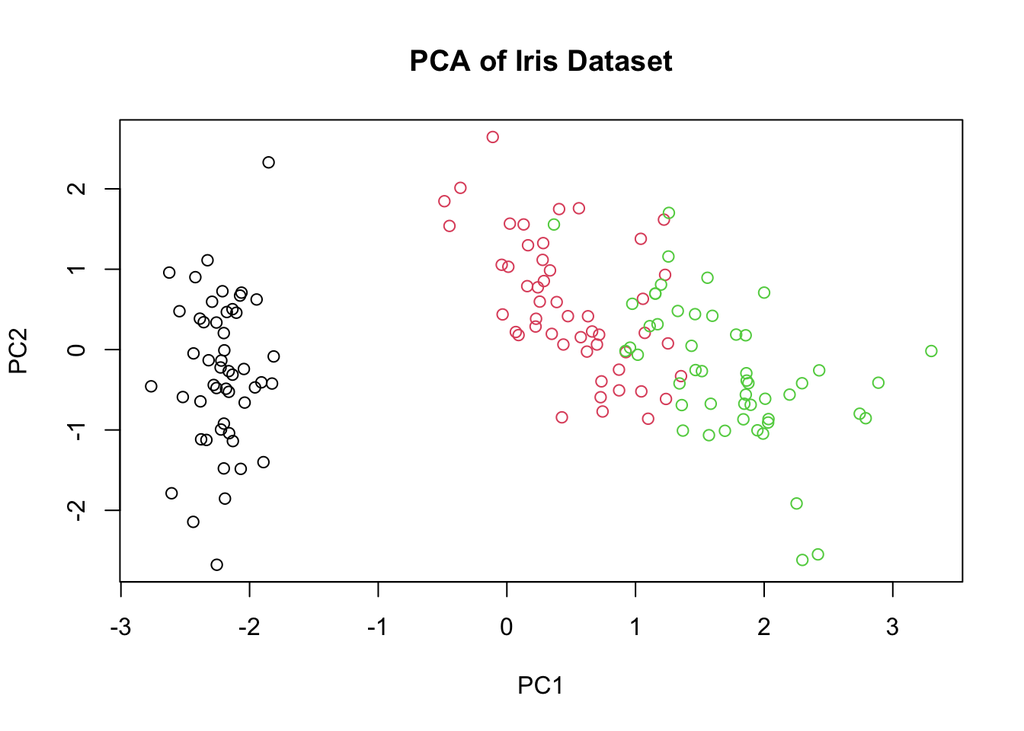

```r
# PCA on the iris dataset
iris_pca <- prcomp(iris[,1:4], scale. = TRUE)
plot(iris_pca$x[,1:2], col = iris$Species, xlab = "PC1", ylab = "PC2", main = "PCA of Iris Dataset")
```

These examples and detailed explanations provide a comprehensive guide to understanding and applying descriptive statistics and data visualization techniques in R. They are crucial for any data analysis, enabling insightful interpretation and effective communication of results.